# Simulation Setup

Sarah Gaichas

2026-10-29

## 1 Introduction

Can we setup our Rpath Mid Atlantic model to do both Risk Policy and ABC sims? What would need to be done in single species SPASM.MSE models?

Testing of the Mid Rpath was done [here](https://sgaichas.github.io/MAB-Rpath/MAB_MSE_test.html), including adding the MAFMC Risk Policy and implementing it in the MSE loop.

Testing of the SPASAM.MSE is [here in general](https://sgaichas.github.io/spasam-mse-test/TestInstallation.html) with the [MAFMC risk policy implemented](https://sgaichas.github.io/spasam-mse-test/TestMAFMC_HCR.html), here a start on [summer flounder](https://sgaichas.github.io/spasam-mse-test/SummerFlounderTest.html), here a start on [butterfish](https://sgaichas.github.io/spasam-mse-test/ButterfishTest_MAFMC_HCR.html) using the actual assessment

SPASAM.MSE needs:

1. simplify the OMs, use output of summer flounder test as input
2. butterfish needs more work on the HCR because the SSC subs in 2/3 M as FOFL and the model running internally estimated FOFL makes it clear that this is a good idea–FOFL is so high that you crash the stock and the EMs can’t converge. also we don’t really need the actual stock assessment to condition the OM for this

Rpath Needs:

1. internally consistent reference points. estimating them from production model for Rpath is probably is best but perturbing with stock specific F may be more effective than trying the effort based forcing done originally to get time series for parameter estimation. alternatively: examine the catch by fleet to back out how much effort to apply across fleets to get better estiamtes
2. add drivers for ABC indicator testing (and to push the model away from its equilibrium). drivers can be bottom up at first, model productivity trends or step changes
3. ensure fleets are operating reasonably
4. what level of parameter uncertainty should we use? full ecosense may be useful, then I need to estimate ref pts from each kept system

What does the simulation need to do

1. Adjust risk policy parameters selectively by stock
2. Adjust ABC selectively by stock
3. Allocate to fleets? commercial vs rec?
4. Output stock levels
5. Output catch levels (which are our only proxy for revenue)
6. Compare stock, “F” and catch with target and threshold level
7. Compare fleet performance
8. What is catch composition? feeds back into what other options fleets have
9. Are there system level issues (Sarah W’s resilience)

How often should we adjust reference points (do an “assessment”) – not sure I want to focus on this

How far away from the assessment are reference points still good – could estimate after intervals to see

Are there indicator based reference points if you dont have an assessment – here try the favorable-neutral-unfavorable approach in Pacific? See ABC Setting The simplest process is start with current ABC and adjust based on indicators

## 2 Rpath

This model is used in S. [Weisberg et al 2026](https://esajournals.onlinelibrary.wiley.com/doi/10.1002/eap.70303), comparing all three NEUS Rpaths.

This model does include discards, despite its name.

Which species are caught in which fleets? The point is to determine which fleets to manipulate to create time series for simple reference point estimation. A stronger fishing signal with heavy fishing followed by recovery makes the production model more likely to converge with decent parameters.

Also this is a basic test of model setup. Do the fleets look similar enough to “real” ones for testing? The main focus is on the MAFMC managed species. Fleet setup affects all simulations and also affects how we interpret social and economic indicators and impacts.

### 2.1 Visualize catches; landings first

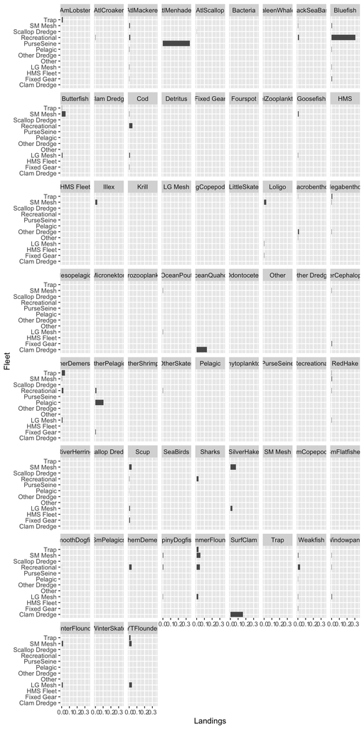

Bluefish rec landings are probably not almost as much as menhaden purse seine landings? check on this. Bluefish EE is very high, perhaps due to this. Any changes to the rec fishery will hammer them.

The most recent management track assessments show [summer flounder](https://www.mafmc.org/s/e_Draft-2025-Summer-Flounder-MT-assessment-report-dn54.pdf) rec landings about 15000 t in the 1980s and [bluefish](https://www.mafmc.org/s/e1_Draft-2025-Bluefish-MT-assessment-report-7eyc.pdf) rec landings around 50000 - 75000 t. So possibly 5 times higher than summer flounder.

Running the MAB_rec_catch.R script with the [MRIP dataset](https://github.com/sgaichas/MAB-Rpath/blob/main/data/mrip_data.RData) in the MAB Rpath repo gets the following (before scaling to MAB area), with bluefish nearly an order of magnitude higher. This should be kg?

```
MAB.mrip_summary |> print(n=Inf)
# A tibble: 23 × 2
   RPATH                 catch
   <chr>                 <dbl>
 1 AtlCroaker          345251.
 2 AtlMackerel        1540585.
 3 BlackSeaBass       1737885.
 4 Bluefish          34452648.
 5 Butterfish             458.
 6 Cod                4580805.
 7 Goosefish             9774.
 8 Mesopelagics          1102.
 9 OtherDemersals     2579641.
10 OtherPelagics      1597042.
11 OtherSkates         354956.
12 RedHake             298367.
13 RiverHerring          4815.
14 Scup                435295.
15 Sharks             3100631.
16 SilverHake           73532.
17 SmPelagics               0
18 SmoothDogfish       112891.
19 SouthernDemersals  3546106.
20 SpinyDogfish        785724.
21 SummerFlounder     4600535.
22 Weakfish           3356023.
23 Windowpane           41383.
```

Bluefish may be overestimated, menhaden may be underestimated, or both. Coastwide catches of [menhaden were 350000 t in the early 1980s](https://asmfc.org/species/atlantic-menhaden/), an order of magnitude more than the bluefish rec catch above.

A fix might be to scale bluefish rec catch to 5x summer flounder, although perhaps the MRIP catch above is feasible. Menhaden could be scaled up 10x?

We are looking at a subset of the range of some of these stock assessments though.

Looking at landings data for the MAB from `ecodata` may help diagnose the model. It is aggregated but breaks out MAFMC managed species in each functional group.

This is from the ecodata commercial landings and revenue dataset. The standard plot shows the dominance of non-Council non-seafood in landings, which is menhaden

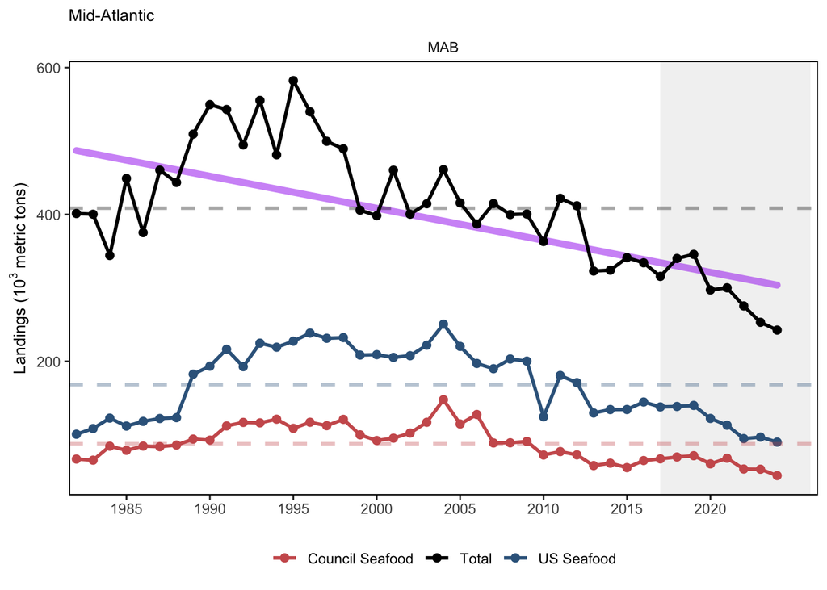

We can zoom in on the guilds for total and MAFMC managed (seafood) landings. This reinforces that we should have an order of magnitude higher landings for menhaden (total planktivore) than other species in the MAB. Mackerel may also be high in the 80s but nothing close to menhaden. Mackerel would only be in the red line if it were landed as seafood.

Next highest landings should be combined benthos (surfclam and ocean quahog with smaller amounts of scallops in the total).

Piscivores get complicated as total landings is commercial only and doesn’t include the substantial recreational landings in the region, or the substantial discards of the jointly managed spiny dogfish. Still combined commercial MAFMC piscivore landings should be about half the MAFMC benthos landings in the early 80s.

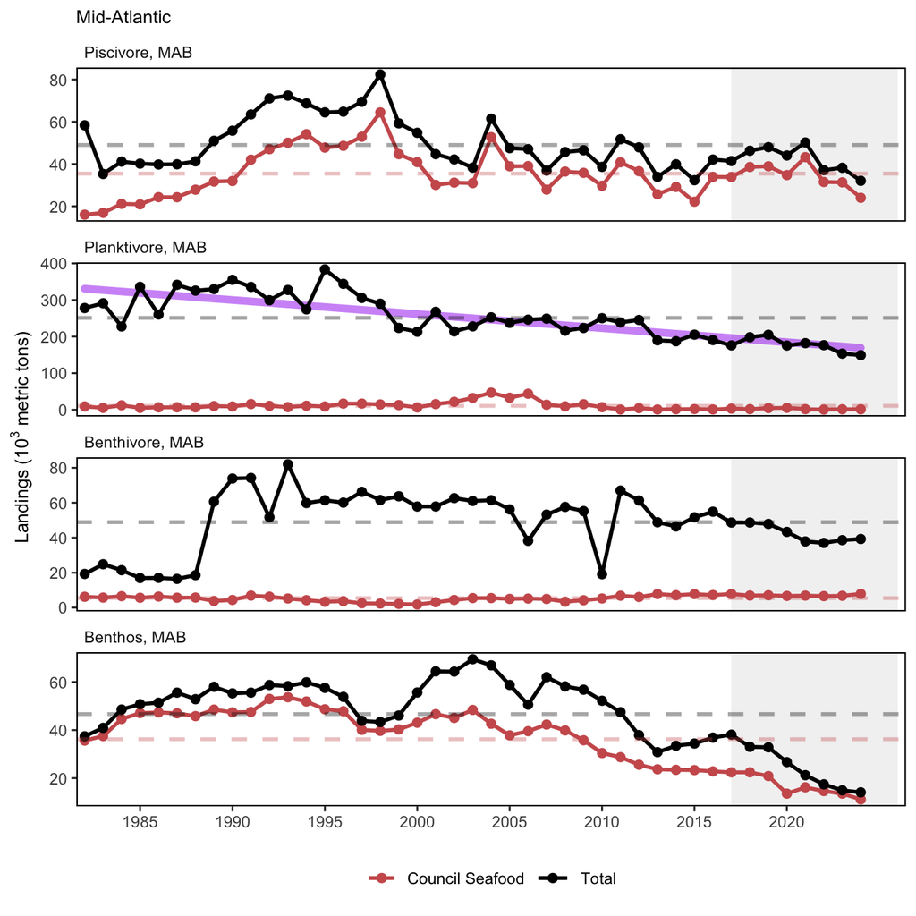

Model landings by MAFMC guild only:

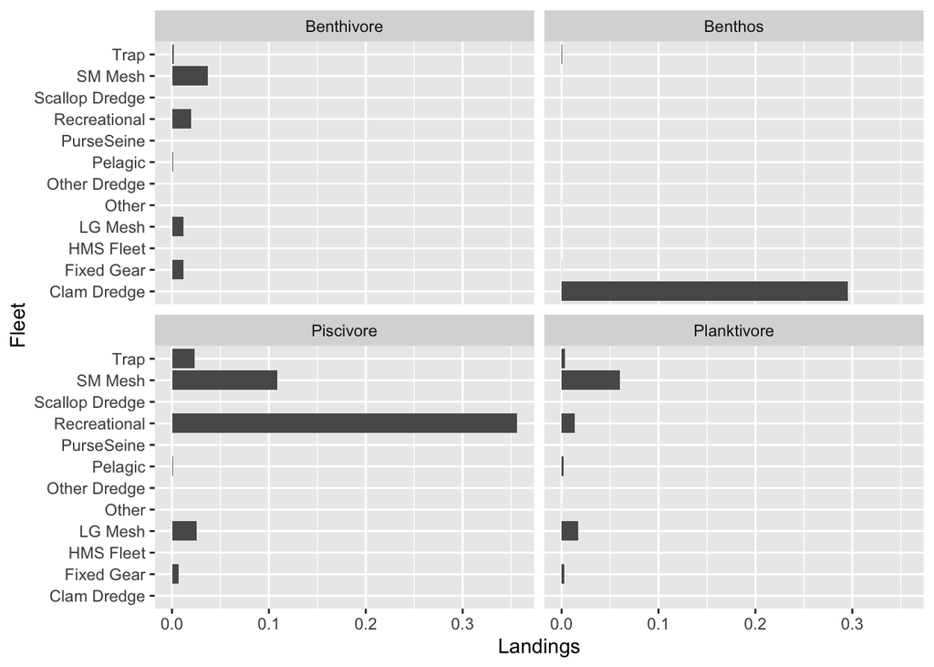

The groupings

| Guild | Group |
| --- | --- |
| Benthivore | BlackSeaBass |
| Benthivore | Scup |
| Benthos | OceanQuahog |
| Benthos | SurfClam |
| Piscivore | Bluefish |
| Piscivore | Illex |
| Piscivore | Loligo |
| Piscivore | SpinyDogfish |
| Piscivore | SummerFlounder |
| Planktivore | AtlMackerel |
| Planktivore | Butterfish |

So are rec landings of all piscivores > than commercial landings of both clams?

### 2.2 Now discards

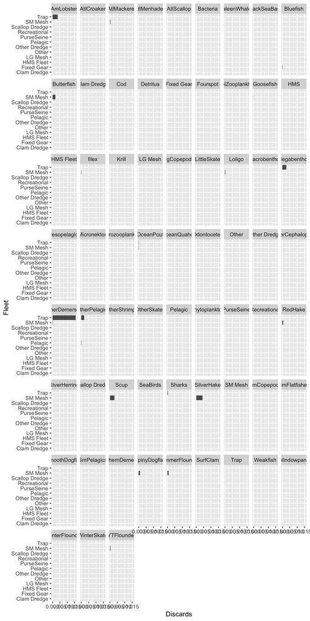

Maybe we also need some adjustments to discards? There were not discard estimates for the early 1980s; these are from observer data which may be sparse.

MAFMC managed discards by guild. Very small and primarily from small mesh?

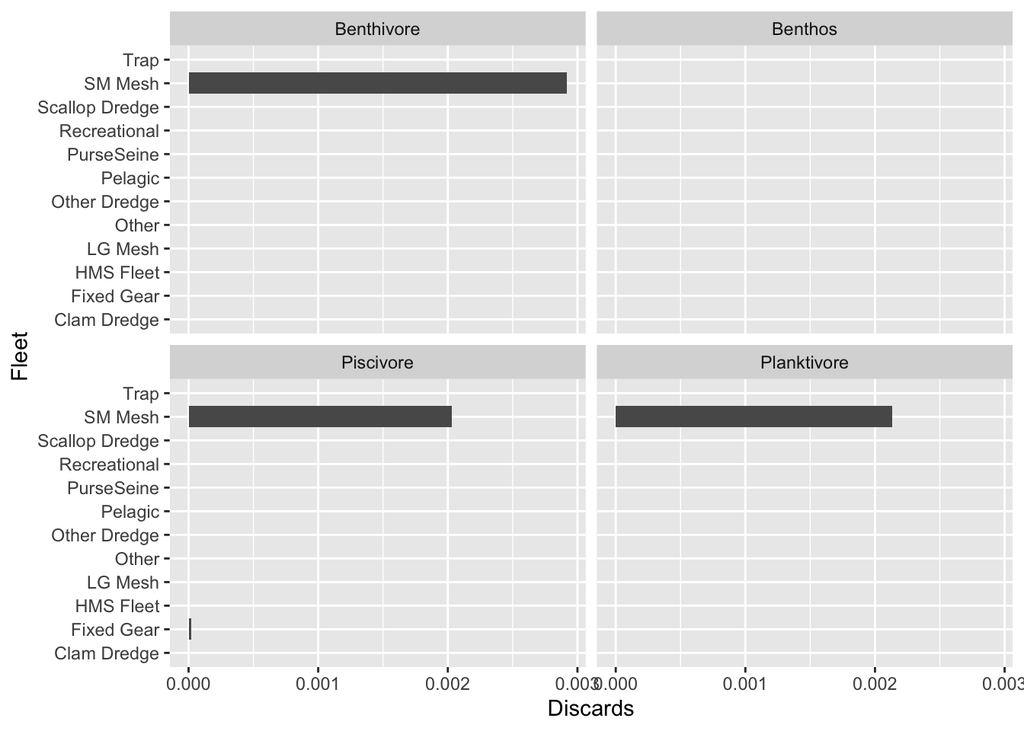

Maybe a patch would be to add discards for spiny dogfish to reflect the higher fishing mortality? EEs are low for them. EEs are very high for other predators in this model (summer flounder, sharks, odontocetes).

Model landings and discards for spiny dogfish also make me question whether the scale of rec landings and commercial landings are comparable. Rec landings are higher in the model than commercial gear landings but they have never been higher than any other component of catch according to the latest MT assessment.

| Group | Fleet | Landings | Discards |
| --- | --- | --- | --- |
| SpinyDogfish | Fixed Gear | 0.000009978088 | 0.0000000000 |
| SpinyDogfish | LG Mesh | 0.001331438746 | 0.0000000000 |
| SpinyDogfish | HMS Fleet | 0.000000000000 | 0.0000000000 |
| SpinyDogfish | Scallop Dredge | 0.000000000000 | 0.0000000000 |
| SpinyDogfish | Trap | 0.000000000000 | 0.0000000000 |
| SpinyDogfish | Other Dredge | 0.000000000000 | 0.0000000000 |
| SpinyDogfish | Other | 0.000000000000 | 0.0000000000 |
| SpinyDogfish | Clam Dredge | 0.000000000000 | 0.0000000000 |
| SpinyDogfish | Pelagic | 0.000000000000 | 0.0000000000 |
| SpinyDogfish | SM Mesh | 0.004818593457 | 0.0009039106 |
| SpinyDogfish | Recreational | 0.007022570057 | 0.0000000000 |
| SpinyDogfish | PurseSeine | 0.000000000000 | 0.0000000000 |

Dead discards of spiny dogfish were estimated for the years 1981-1985 in [this document](https://static1.squarespace.com/static/511cdc7fe4b00307a2628ac6/t/54174a1ce4b06556b71702cf/1410812444015/2014+Status+Report+for+spiny+dogfish_final.pdf). They were 2-3 times the landings. Subbing in mean dead discards for otter trawls in these years may be reasonable, as [discards are still roughly equal to catch for spiny dogfish–see Fig 4](https://www.mafmc.org/s/e1_2023-Spiny-Dogfish-MT-assessment-report.pdf).

The current model construction methods in MAB_discards.R to derive a discard:landings ratio from observer data and apply it to landings to get the discards matrix. A discard rate is also used to establish quotas. We could try a discard:landings ratio based on the early 1980s estimates (2.5) or a discard rate based on [current management estimates (see Table 1)](https://www.mafmc.org/s/a_2026-Staff_ABC_Memo-spinys.pdf). The current percent discard applied to total catch is 43%, so the split is landings 4,284 t and discards 3,338 t for a discard:landings ratio of 0.78

### 2.3 Update Recreational Landings

The full rec landings dataset was updated to account for the 2026 recalibration.

See notes [here](https://mafmc.github.io/indicators-project-docs/MRIPdat.html) on MRIP datasets and test comparisons.

At present, the dataset derived from assembling `mrip_catch_bywave_YYYY.csv` for all YYYY 1981-2025 is used as the basis for model recreational landings, as it appears most similar to the source data used previously. I have one email out asking about some discrepancies in posted MRIP catch data, so this may get updated later if I need to do the catch estimation myself.

Individual csv files were downloaded from here: https://apps-st.fisheries.noaa.gov/st1/recreational/MRIP_Estimate_Data/CSV/Wave%20Level%20Estimate%20Downloads/ Code that derived the [dataset used here](https://github.com/MAFMC/indicators-project-data/blob/main/data-raw/MRIP/allbywave19812025.rds) is posted [here](https://github.com/MAFMC/indicators-project-data/blob/main/R/read_mrip_catch_bywave.R).

Keeping the estimation code the same aside from the input dataset, we have these estimated recreational landings in kg:

```
>> MAB.mrip_summary |> print(n=Inf)
# A tibble: 23 × 3
   RPATH                 catch   Per_Area
   <chr>                 <dbl>   [1/km^2]
 1 AtlCroaker          206804. 0.00185
 2 AtlMackerel        1337799. 0.0120
 3 BlackSeaBass       1566485  0.0140
 4 Bluefish          28076467. 0.251
 5 Butterfish             196. 0.00000175
 6 Cod                4142376. 0.0370
 7 Goosefish             9677  0.0000865
 8 Mesopelagics           337  0.00000301
 9 OtherDemersals     1320919. 0.0118
10 OtherPelagics      1091325. 0.00975
11 OtherSkates         186402. 0.00167
12 RedHake             285478. 0.00255
13 RiverHerring          2438  0.0000218
14 Scup                302471. 0.00270
15 Sharks             2495675. 0.0223
16 SilverHake           59873. 0.000535
17 SmPelagics               0  0
18 SmoothDogfish        72073. 0.000644
19 SouthernDemersals  2301793  0.0206
20 SpinyDogfish        625037. 0.00559
21 SummerFlounder     2657502. 0.0238
22 Weakfish           2041603  0.0182
23 Windowpane           22969. 0.000205
```

The recalibrated MRIP time series generally results in lower landings in the 1980s. Bluefish is still highest. The high recreational landings of bluefish are reflected across all other MRIP data including the official web query, so this number stays here.

I’ll replace the recreational landings in the model with this full set. This will be a whole new model building script in MAB Rpath: `MAB_Rpath_2026.R`

### 2.4 Update menhaden landings

The question now for landings is less was bluefish really that high and more why is menhaden so low? ASMFC lists catch of Atlantic menhaden as 350,000 t in the early 1980s. [The Fisheries of the US from 1980](https://repository.library.noaa.gov/view/noaa/17068/noaa_17068_DS1.pdf) also lists menhaden landings. They are not split to Mid-Atlantic but coastwide Atlantic was about 430,000 t and Chesapeake Bay total landings (of all species) were 325,000 metric tons. I think it would be safe to set menhaden landings for the Mid-Atlantic (which includes the stock caught in the Chesapeake Bay) in the 300,000 t range for the early 1980s. With an area of 111,886 square km this would be a density of 2.6813 t/sq km. We’ll use that for now until I can get a better estimate.

### 2.5 Update discards

The published model reduced dogfish biomass for balance. Here we will add in dogfish discards

The MAB Rpath model did not previously consider dead recreational releases, which would be included under discards.

This is the model structure, including fleets. One strange thing is the HMS Fleet has 0 catch so it breaks the plotting function. We should either take the HMS Fleet out or add real catch of HMS. For this figure, HMS catch totalling 10% of HMS biomass was added. We are not using this model for analysis

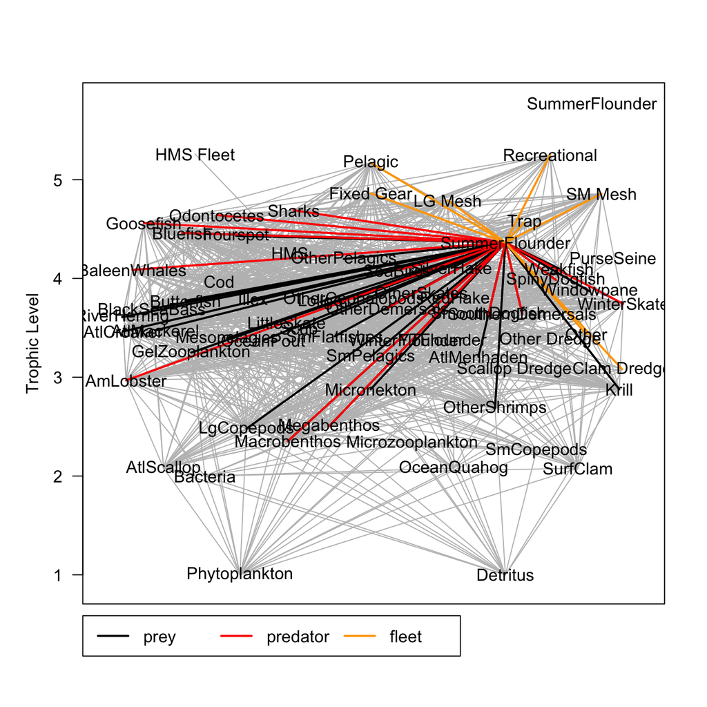